# Homework 4

Ziyang (Bob) Ding

17 February, 2020

## Problem 1

**Consider a bivariate normal population with $\mu_{1}=0, \mu_{2}=2, \sigma_{11}=2, \sigma_{22}=1$ and $\rho_{12}=.5$**

- **(a)** **Write out the Mahalanobis distance to the mean as a function of $x_{1}$ and $x_{2}$**
- **(b)** **Evaluate the density at the point $x=(1,2)$**
- **(c)** **Determine and sketch the constant-density countour that contains $50 \%$ of the probability. (Hint: use the population principal components ).**

**Proof**

- **(a)**

### DISCLAIMER: SORRY! I RELAIZED THAT I MESSED UP THE OFF DIAGONAL VALUE OF THE COVARIANCE MATRIX. IT SHOULD BE $\frac{\sqrt{2}}{2}$. BUT I THINK I ALREADY UNDERSTAND EVERYTHING ABOUT THIS QUESTION THEREFORE I DIDN’T CHANGE THE OFF DIAGONAL TERM AND JUST KEPT USING 0.5. PLEASE DON’T TAKE POINT OFF FROM ME. TRUST ME, I UNDERSTAND IT. THANK YOU!

We know that the Mahalanobis distance is in the form of

$$\begin{aligned}
(x-\mu)^{\prime} \Sigma^{-1}(x-\mu)=\sum_{i=1}^{p} \sum_{j=1}^{p} \sigma^{i j}\left(x_{i}-\mu_{i}\right)\left(x_{j}-\mu_{j}\right)
\end{aligned}$$

Therefore, we just take into the value:

$$\begin{aligned}
\begin{bmatrix}
x_1 & x_2-2
\end{bmatrix}
\begin{bmatrix}
2 & 0.5\\
0.5 & 1
\end{bmatrix}^{-1}
\begin{bmatrix}
x_1\\
x_2-2
\end{bmatrix} &=
\begin{bmatrix}
x_1 & x_2-2
\end{bmatrix}
\begin{bmatrix}
\frac{4}{7} & -\frac{2}{7}\\
-\frac{2}{7} & \frac{8}{7}
\end{bmatrix}
\begin{bmatrix}
x_1\\
x_2 -2
\end{bmatrix}
\end{aligned}$$

- **(b)**

Just plugin the value we get

$$\begin{aligned}
\begin{bmatrix}
1 & 0
\end{bmatrix}
\begin{bmatrix}
2 & 0.5\\
0.5 & 1
\end{bmatrix}^{-1}
\begin{bmatrix}
1\\
0
\end{bmatrix} &=
\begin{bmatrix}
1 & 0
\end{bmatrix}
\begin{bmatrix}
\frac{4}{7} & -\frac{2}{7}\\
-\frac{2}{7} & \frac{8}{7}
\end{bmatrix}
\begin{bmatrix}
1\\
0
\end{bmatrix} = \frac{4}{7}
\end{aligned}$$

- **(c)**

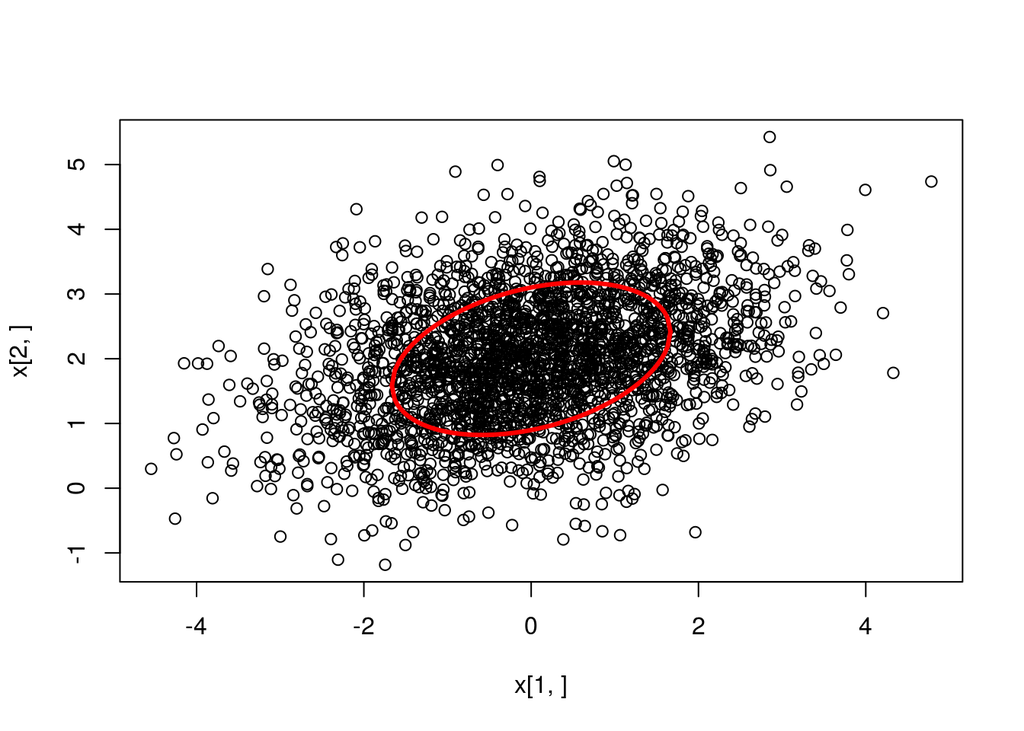

```r
sig=matrix(c(2,1/2,1/2,1),nrow=2)
L=t(chol(sig))
mu=matrix(c(0,2),ncol=1)
r=matrix(rnorm(5000),nrow=2)
x=apply(L%*%r,2,function(t) t+mu)
m=qgamma(0.5,1,1/2)
y1=seq(-sqrt(m),sqrt(m),length.out = 100)
y2=sqrt(m-y1^2)
ell=apply(L%*%rbind(y1,y2),2,function(t) t+mu)
plot(x[1,],x[2,])
lines(ell[1,],ell[2,],col='red', lwd = 3)
lines(2*mu[1]-ell[1,],2*mu[2]-ell[2,],col='red', lwd=3)
```

## Problem 2

**Let $X$ be distributed as $N_{3}(\mu, \Sigma)$ where $\mu=[1,-1,2]$ and**

$$\Sigma=\left[\begin{array}{ccc}{4} & {0} & {-1} \\ {0} & {5} & {0} \\ {-1} & {0} & {2}\end{array}\right]$$
**Which of the following random variables are independent? Explain.**

- **(a)** **$X_{1}$ and $X_{2}$**
- **(b)** **$X_{1}$ and $X_{3}$**
- **(c)** **$X_{2}$ and $X_{3}$**
- **(d)** **$\left(X_{1}, X_{3}\right)$ and $X_{2}$**
- **(e)** **$X_{1}$ and $X_{1}+3 X_{2}-2 X_{3}$**

**Proof**

- **(a)** **$X_{1}$ and $X_{2}$**

Yes, they are independent

- **(b)** **$X_{1}$ and $X_{3}$**

No, they are not independent

- **(c)** **$X_{2}$ and $X_{3}$**

Yes, they are independent

- **(d)** **$\left(X_{1}, X_{3}\right)$ and $X_{2}$**

Yes, they are independent, as the off block diagonal term is purely zero (for sure we need to rearrange the matrix a bit. Then we will know)

- **(e)** **$X_{1}$ and $X_{1}+3 X_{2}-2 X_{3}$**

$$\begin{aligned}
\quad &\mathbb{E}[ (X_1)(X_{1}+3 X_{2}-2 X_{3}) ] - \mathbb{E}[X_1]\mathbb{E}[X_{1}+3 X_{2}-2 X_{3} ]\\
= &\mathbb{E}[ X_1^2 + 3X_1X_2 - 2X_1X_3 ] - 4 (1-6-4)\\
= & (1+4) +3(-1) -2(2-1)+ 36\\
= & 5 - 3 -2 + 36\\
= & 36 \neq 0
\end{aligned}$$

No, they are not independent

## Problem 3

**Suppose $X$ and $Y$ are independent random vectors with**

$$\begin{aligned}
X=\left(\begin{array}{l}
{X_{1}} \\
{X_{2}}
\end{array}\right) \sim N\left(\left(\begin{array}{l}
{0} \\
{0}
\end{array}\right),\left(\begin{array}{cc}
{1} & {\rho_{1}} \\
{\rho_{1}} & {1}
\end{array}\right)\right) \text { and } Y=\left(\begin{array}{l}
{Y_{1}} \\
{Y_{2}}
\end{array}\right) \sim N\left(\left(\begin{array}{l}
{0} \\
{0}
\end{array}\right),\left(\begin{array}{cc}
{1} & {\rho_{2}} \\
{\rho_{2}} & {1}
\end{array}\right)\right)
\end{aligned}$$
**Define**

$$\begin{aligned}
\begin{array}{l}
{\qquad U=\left(\begin{array}{c}
{U_{1}} \\
{U_{2}}
\end{array}\right)=A\left(\begin{array}{c}
{X_{1}} \\
{Y_{1}}
\end{array}\right) \quad \text { and } \quad V=\left(\begin{array}{c}
{V_{1}} \\
{V_{2}}
\end{array}\right)=A\left(\begin{array}{c}
{X_{2}} \\
{Y_{2}}
\end{array}\right)}
\end{array}
\end{aligned}$$
**for**

$$\begin{aligned}
\begin{array}{l}
{\qquad A=\left(\begin{array}{ll}
{a_{11}} & {0} \\
{a_{21}} & {a_{22}}
\end{array}\right)}
\end{array}
\end{aligned}$$
Show that $U_{1} \perp\!\!\!\perp V_{2} | V_{1}$

**Proof**

We first notice that:

$$\begin{aligned}
U_1 &= a_{11}X_1 \\
U_2 &= a_{21}X_1 + a_{22}Y_2 \\
V_1 &= a_{11}X_2\\
V_2 &= a_{21}X_2 + a_{22}Y_2
\end{aligned}$$
Therefore, as long as $X_1$ is given, then the induced sigma field of $V_2 | V_1$ can be written out as

$$\begin{aligned}
U_1 &= a_{11}X_1\\
V_2 | V_1 &= a_{22}Y_2 + \frac{a_{21}}{a_{11}}V_1
\end{aligned}$$

In this way, because we know that both of them follow Normal distribution, and that $X_1 \perp\!\!\!\perp Y_1$. Therefore, we know that $U_1 \perp\!\!\!\perp V_2|V_1$

## Problem 4

**(Bayesian missing data problem) We are given the following set of (incomplete) bivariate observations:**

$$\begin{align}
P(\boldsymbol{\Sigma}) \propto|\boldsymbol{\Sigma}|^{-3 / 2}
\end{align}$$
**yielding the complete-data posterior:**

$$\begin{align}
P\left(\boldsymbol{\Sigma} | \mathbf{y}_{i}, i=1, \ldots, n\right) \propto|\boldsymbol{\Sigma}|^{\frac{-3+n}{2}} e^{-\frac{1}{2} t r\left(\Sigma^{-1} \mathbf{s}\right)}
\end{align}$$

**where $\mathbf{S}$ is the sample sum-of-squares matrix. This is an inverse-Wishart(n, S) distribution (Gelman et al, 1995 ).**

- **(a)** **Write down the (multiple) integral defining $\mu_{\rho}=\mathrm{E}(\rho |$ yobserved ), the marginal posterior expectation of $\rho .($ Hint: you will need to integrate out the missing data..) You do not need to solve this integral analytically; we will solve by importance sampling below.**
- **(b)** **Give $\pi\left(\Sigma | \mathbf{y}_{1}, \ldots, \mathbf{y}_{4}\right),$ the (partial) posterior obtained by considering only the data points without missing values. Using the $r$Wishart() function in $\mathrm{R},$ construct a Monte Carlo estimate of the marginal distribution of $\rho$ under this partial posterior.**
- **(c)** **Show that by combining this partial posterior with the known conditional distribution of $y | \Sigma$, we can construct an instrumental distribution $g$ for obtaining a Monte Carlo approximation of $\mu_{\rho}$ via importance sampling. (Hint: from part (a), notice that $g$ should be a distribution on both $\Sigma$ and the missing data. $)$**
- **(d)** **Implement your importance sampling algorithm. Use it to**
  - **[i]**. **Estimate $\mu_{\rho}$**
  - **[ii]**. **Estimate/plot $\pi\left(\rho | \mathbf{y}_{1}, \ldots, \mathbf{y}_{12}\right) .$ Does it look reasonable? Explain.**
- **(e)** **Perform appropriate importance sampling diagnostics. Do you trust your results?**

**Proof**

- **(a)**

$$\begin{aligned}
p\left(y_{i} | \Sigma\right) &=\frac{1}{2\pi \sigma_{1} \sigma_{2} \sqrt{1-p^{2}}} \exp \left\{-\frac{1}{2}\left(1-p^{2}\right)^{-1}\left(\frac{y_{i}^{2}}{\sigma_{1}^{2}}+\frac{y_{i_{2}}^{2}}{\sigma_{2}^{2}}-\frac{2 \rho {y_{i1} y_{i2}}}{\sigma_{1} \sigma_{2}}\right)\right\}\\
p(y | \Sigma)&=(2 \pi)^{-n}\left(\sigma_{1} \sigma_{2}\right)^{-n}\left(1-p^{2}\right)^{-\frac{n}{2}} \exp \left\{-\frac{1}{2\left(1-\rho^{2}\right)} \sum_{i=1}^{n}\left(\frac{y_{i}^{2}}{\sigma_{1}^{2}}+\frac{y_{i 2}^{2}}{\sigma_{2}^{2}}-\frac{2 \rho y_{i 1} y_{i 2}}{\sigma_{1} \sigma_{2}}\right)\right\}\\
p(y, \Sigma) &\propto(2 \pi)^{-n}\left(\sigma_{1} \sigma_{2}\right)^{-n}\left(1-p^{2}\right)^{-\frac{n}{2}}\left(\sigma_{1}^{2} \sigma_{2}^{2}\left(1-\rho^{2}\right)\right)^{-\frac{3}{2}} \exp \left\{-\frac{1}{2\left(1-\rho^{2}\right)} \sum_{i=1}^{n}\left(\frac{y_{i1}^{2}}{\sigma_{1}^{2}} \frac{y_{i_{2}}^{2}}{\sigma_{2}^{2}}-\frac{2 \rho y_{i1} y_{i2}}{\sigma_{1} \sigma_{2}}\right)\right\}\\
p(\rho | y) &\propto p(\Sigma | y) d \sigma_{1} d \sigma_{2} \\
p\left(\rho | y_{obs}\right) & \propto \int p\left(\rho, y_{obs}, y_{m i s}\right) d y_{m i s} \\
&\left.\alpha \int p(y, \Sigma) d \sigma_{1} d \sigma_{2}\right) d y_{m i s} \\
& \propto \int\left(\sigma_{1} \sigma_{2}\right)^{-(n+3)}\left(1-p^{2}\right)^{-\frac{1}{2}(n+3)} \exp \left\{-\frac{1}{2\left(1-p^{2}\right)}\sum_{i=1}^n\left( \frac{y_{i1}^{2}}{\sigma_{1}^{2}}+\frac{y_{i2}^{2}}{\sigma_{2}^{2}}-\frac{2 \rho y_{i 1} y_{i 2}}{\sigma_{1} \sigma_{2}}\right)\right\} d \sigma_{1} d\sigma_2 d y_{m i s}\\
E\left(\rho | y_{0 b s}\right) &=\int \rho p\left(\rho | y_{0 k s}\right) d \rho \\
&=\frac{\int p\left(1-\rho^{2}\right)-\frac{1}{2}(n+3)^{-(n+3)} \exp \left\{-\frac{1}{2\left(1-\rho^{2}\right)} \sum_{i=1}^{n}\left(\frac{y_{i1}^{2}}{v_{1}^{2}}+\frac{y_{i 2}^{2}}{\sigma_{2}^{2}}-\frac{2 \rho y_{i1} y_{i 2}}{\sigma_{1} \sigma_{2}}\right) d \sigma_{1} d \sigma_{2} d y_{mis}\right] d \rho}{\int\left(1-\rho^{2}\right)^{-\frac{1}{2}(n+3)}\left[\int\left(\sigma_{1} \sigma_{2}\right)^{-(n+3)} \exp \left\{-\frac{1}{2\left(1-\rho^{2}\right)} \sum_{i=1}^{n}\left(\frac{y_{i1}^{2}}{\sigma_{1}^{2}}+\frac{y_{i2}^{2}}{\sigma_{2}^{2}}-\frac{2 \rho y_{i 1} y_{i 2}}{\sigma_{1} \sigma_{2}}\right) d \sigma_{1} d \sigma_{2} d y_{mis}\right] d \rho\right.}
\end{aligned}$$

- **(b)**

We know that this will follow a Inverse-Wishard Distribution of inverse-Wishart(n, S). Therefore, we just need to sample a lot of $\Sigma$ from such distribution.

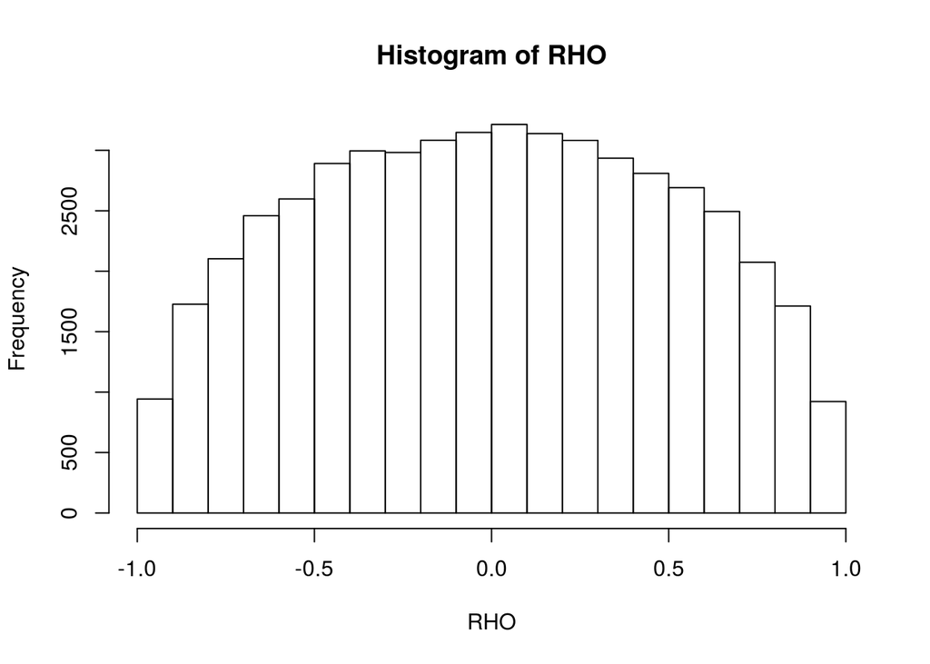

```r
# Make the observed data
observed_y <- list(matrix(c(1,1), nrow=2, ncol = 1),
                   matrix(c(1,-1), nrow=2, ncol = 1),
                   matrix(c(-1,1), nrow=2, ncol = 1),
                   matrix(c(-1,-1), nrow=2, ncol = 1))

# Make the big S matrix
S <- matrix(c(0,0,0,0), nrow = 2, ncol = 2, byrow = TRUE)
for(i in observed_y){
  S = S + i %*% t(i)
}

# Make function to get $\rho$ from the \Sigma
getRho <- function(Sigma){
  rho <- Sigma[1,2]  / sqrt(Sigma[1,1] * Sigma[2,2] )
  return(rho)
}

sumOfRhos <- 0
df <- 4
n <- 50000
inverseS <- solve(S)
RHO=rep(0,n)
for (i in 1:n){
  rw=rWishart(1,df,inverseS)
  riw=solve(rw[,,1])
  rho=getRho(riw)
  RHO[i]=rho
}

hist(RHO)
```

```r
mean(RHO)
```

```
## [1] 4.398131e-05
```

- **(c)**

$$\begin{aligned}
&\mu_{p}=\int \rho \pi\left(\Sigma | y_{obs }\right) d \varepsilon=\int \rho \frac{P\left(Y_{obs 5:12} | \Sigma\right) p\left(\Sigma | Y_{1:4}\right) p\left(Y_{1:4} \right)}{p\left(Y_{obs}\right)} d \Sigma\\
\end{aligned}$$

Take $g=p\left(\Sigma | Y_{1: 4}\right)$, $w=p\left(Y_{obs 5:12} | \Sigma\right)$, and $\hat{w}=\frac{w}{\sum_{j=1}^{N} w_{j}}$

- **(d)**

```r
set.seed(1)
library(mvtnorm)

N=100000
wei=rep(0,N)
hx=rep(0,N)
rho_x=seq(-1.01,1.01,length.out = 80)
ind=matrix(0,nrow = N,ncol=80)
for (i in 1:N){
rw=rWishart(1,df,inverseS)
riw=solve(rw[,,1])
hx[i]=riw[1,2]/sqrt(riw[1,1]*riw[2,2])
for (j in 1:79){ind[i,j]=1*(hx[i]> rho_x[j] && hx[i]<= rho_x[j+1])}
wei[i]=prod(dnorm(c(2,2,-2,-2),0,sqrt(riw[1,1])))*prod(dnorm(c(2,2,-2,-2),0,sqrt(riw[2,2])))
}
wei_renorm=wei/sum(wei)

# Mean
(mu_rho=sum(hx*wei_renorm))
```

```
## [1] -0.001016352
```

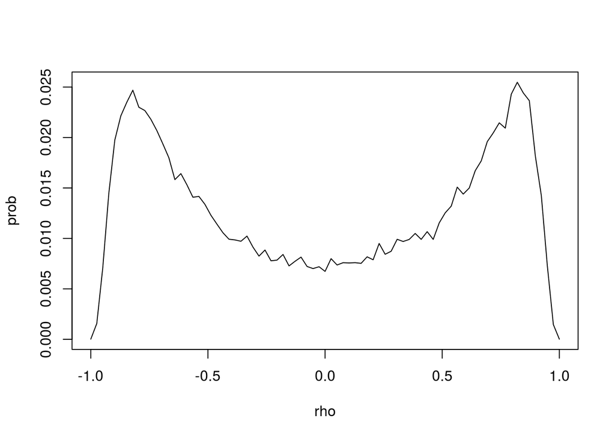

```r
# Dist
dens=apply(ind,2,function(col){sum(col*wei_renorm)})
plot(seq(-1,1,length.out=79),dens[1:79],type='l', xlab='rho', ylab='prob')
```

- **(e)**

```r
ess=N*(mean(wei_renorm))^2/mean(wei_renorm^2)
ess
```

```
## [1] 30911.23
```

We can trust this result. This is pretty good though.